# Cleaning of the data

Jono Tuke

Dec 2019

# 1 Read in the data

```r
TSH  <- read_excel("../raw data/20191206_excel TSHV3.xlsx")
TSH
```

| hyper/hypo | Paper | Continuous V quantile | Condition and restrictions on cohorts | Condition Classification | System | FT4_N | FT4_method | FT4_Sig | FT4_PV | FT4_Sophistication | FT4_cov | TSH_N | TSH_method | TSH_Sig | TSH_PV | TSH_Sophistication | TSH_cov | T3_N | T3_method | T3_Sig | T3_PV | T3_Sophistication | T3_cov | T3 - Free or Total | Include? | NOS score | TSH incong | cross-section | abstract score |
| --- | --- | --- | --- | --- | --- | --- | --- | --- | --- | --- | --- | --- | --- | --- | --- | --- | --- | --- | --- | --- | --- | --- | --- | --- | --- | --- | --- | --- | --- |
| hyper | Cappola et al | Continuous | AF | AF | Cardiac | 2673 | Cox PH | Y | < 0.001 | Medium | Age, sex, race, initiation of Thyroid Hormone replacement | 2673 | Cox PH | N | 0.09 | Medium | Age, sex, race, initiation of Thyroid Hormone replacement | 2673 | Cox PH | N | 0.4 | Medium | Age, sex, race, initiation of Thyroid Hormone replacement | Total | 1 | 9 | 0 | N | 3 |
| hyper | Cappola et al | Continuous | AF | AF | Cardiac | 2673 | Cox PH | Y | 0.02 | High | Age, sex, race, initiation of Thyroid Hormone replacement and BMI, hypertension, fasting glucose, current smoking, any alcohol, valvular disease history and any use of diuretic or beta-blocker | 2673 | Cox PH | N | 0.12 | High | Age, sex, race, initiation of Thyroid Hormone replacement and BMI, hypertension, fasting glucose, current smoking, any alcohol, valvular disease history and any use of diuretic or beta-blocker | 2673 | Cox PH | N | 0.24 | High | Age, sex, race, initiation of Thyroid Hormone replacement and BMI, hypertension, fasting glucose, current smoking, any alcohol, valvular disease history and any use of diuretic or beta-blocker | Total | 1 | NA | 0 | N | NA |
| hyper | Cappola et al | Continuous | CHD | CAD | Cardiac | 2215 | Cox PH | N | 0.13 | Medium | Age, sex, race, initiation of Thyroid Hormone replacement | 2215 | Cox PH | N | 0.2 | Medium | Age, sex, race, initiation of Thyroid Hormone replacement | 2215 | Cox PH | N | 0.09 | Medium | Age, sex, race, initiation of Thyroid Hormone replacement | Total | 1 | NA | 0 | N | NA |
| hyper | Cappola et al | Continuous | CHD | CAD | Cardiac | 2215 | Cox PH | N | 0.28000000000000003 | High | Age, sex, race, initiation of Thyroid Hormone replacement and BMI, hypertension, diabetes, current smoking, LDL cholesterol, lipid-lowering medication and C-reactive protein | 2215 | Cox PH | N | 0.15 | High | Age, sex, race, initiation of Thyroid Hormone replacement and BMI, hypertension, diabetes, current smoking, LDL cholesterol, lipid-lowering medication and C-reactive protein | 2215 | Cox PH | N | 0.31 | High | Age, sex, race, initiation of Thyroid Hormone replacement and BMI, hypertension, diabetes, current smoking, LDL cholesterol, lipid-lowering medication and C-reactive protein | Total | 1 | NA | 0 | N | NA |
| hyper | Cappola et al | Continuous | Incident Heart failure | other | Cardiac | 2706 | Cox PH | Y | 4.0000000000000001E-3 | Medium | Age, sex, race, initiation of Thyroid Hormone replacement | 2706 | Cox PH | N | 0.17 | Medium | Age, sex, race, initiation of Thyroid Hormone replacement | 2706 | Cox PH | N | 0.54 | Medium | Age, sex, race, initiation of Thyroid Hormone replacement | Total | 1 | NA | 0 | N | NA |
| hyper | Cappola et al | Continuous | Incident Heart failure | other | Cardiac | 2706 | Cox PH | Y | 0.03 | High | Age, sex, race, initiation of Thyroid Hormone replacement and BMI, hypertension, diabetes, current smoking,CHD, AF, stroke, claudication, any alcohol and creatinine (natural log) | 2706 | Cox PH | N | 0.09 | High | Age, sex, race, initiation of Thyroid Hormone replacement and BMI, hypertension, diabetes, current smoking,CHD, AF, stroke, claudication, any alcohol and creatinine (natural log) | 2706 | Cox PH | N | 0.77 | High | Age, sex, race, initiation of Thyroid Hormone replacement and BMI, hypertension, diabetes, current smoking,CHD, AF, stroke, claudication, any alcohol and creatinine (natural log) | Total | 1 | NA | 0 | N | NA |
| hyper | Cappola et al | Continuous | Composite measure of CVD | other | Cardiac | 2073 | Cox PH | Y | 8.0000000000000002E-3 | Medium | Age, sex, race, initiation of Thyroid Hormone replacement | 2073 | Cox PH | N | 0.05 | Medium | Age, sex, race, initiation of Thyroid Hormone replacement | 2073 | Cox PH | N | 0.43 | Medium | Age, sex, race, initiation of Thyroid Hormone replacement | Total | 1 | NA | 0 | N | NA |
| hyper | Cappola et al | Continuous | Composite measure of CVD | other | Cardiac | 2073 | Cox PH | Y | 0.02 | High | Age, sex, race, initiation of Thyroid Hormone replacement and BMI, hypertension, diabetes, current smoking, stroke, claudication, C-reactive protein and creatinine (natural log) | 2073 | Cox PH | Y | 0.04 | High | Age, sex, race, initiation of Thyroid Hormone replacement and BMI, hypertension, diabetes, current smoking, stroke, claudication, C-reactive protein and creatinine (natural log) | 2073 | Cox PH | N | 0.78 | High | Age, sex, race, initiation of Thyroid Hormone replacement and BMI, hypertension, diabetes, current smoking, stroke, claudication, C-reactive protein and creatinine (natural log) | Total | 1 | NA | 0 | N | NA |
| hyper | Cappola et al | Continuous | Hip Fracture | fracture | Bone | 2803 | Cox PH | N | 0.79 | Medium | Age, age^b, sex, race, initiation of Thyroid Hormone replacement | 2803 | Cox PH | N | 0.2 | Medium | Age, age^b, sex, race, initiation of Thyroid Hormone replacement | 2803 | Cox PH | N | 0.73 | Medium | Age, age^b, sex, race, initiation of Thyroid Hormone replacement | Total | 1 | NA | 0 | N | NA |
| hyper | Cappola et al | Continuous | Hip Fracture | fracture | Bone | 2803 | Cox PH | N | 0.56000000000000005 | High | Age, age^b, sex, race, initiation of Thyroid Hormone replacement and oral steriod, ln(exercise kCal), current smoking, alcohol and weight | 2803 | Cox PH | N | 0.26 | High | Age, age^b, sex, race, initiation of Thyroid Hormone replacement and oral steriod, ln(exercise kCal), current smoking, alcohol and weight | 2803 | Cox PH | N | 0.86 | High | Age, age^b, sex, race, initiation of Thyroid Hormone replacement and oral steriod, ln(exercise kCal), current smoking, alcohol and weight | Total | 1 | NA | 0 | N | NA |

[output cut: 867 more lines]

# 2 Cleaning of the data

## 2.1 Missing rows

Blank rows between papers in excel spreadsheet - remove.

```r
TSH  <-
  TSH %>%
  filter(!is.na(Paper))
TSH
```

| hyper/hypo | Paper | Continuous V quantile | Condition and restrictions on cohorts | Condition Classification | System | FT4_N | FT4_method | FT4_Sig | FT4_PV | FT4_Sophistication | FT4_cov | TSH_N | TSH_method | TSH_Sig | TSH_PV | TSH_Sophistication | TSH_cov | T3_N | T3_method | T3_Sig | T3_PV | T3_Sophistication | T3_cov | T3 - Free or Total | Include? | NOS score | TSH incong | cross-section | abstract score |
| --- | --- | --- | --- | --- | --- | --- | --- | --- | --- | --- | --- | --- | --- | --- | --- | --- | --- | --- | --- | --- | --- | --- | --- | --- | --- | --- | --- | --- | --- |
| hyper | Cappola et al | Continuous | AF | AF | Cardiac | 2673 | Cox PH | Y | < 0.001 | Medium | Age, sex, race, initiation of Thyroid Hormone replacement | 2673 | Cox PH | N | 0.09 | Medium | Age, sex, race, initiation of Thyroid Hormone replacement | 2673 | Cox PH | N | 0.4 | Medium | Age, sex, race, initiation of Thyroid Hormone replacement | Total | 1 | 9 | 0 | N | 3 |
| hyper | Cappola et al | Continuous | AF | AF | Cardiac | 2673 | Cox PH | Y | 0.02 | High | Age, sex, race, initiation of Thyroid Hormone replacement and BMI, hypertension, fasting glucose, current smoking, any alcohol, valvular disease history and any use of diuretic or beta-blocker | 2673 | Cox PH | N | 0.12 | High | Age, sex, race, initiation of Thyroid Hormone replacement and BMI, hypertension, fasting glucose, current smoking, any alcohol, valvular disease history and any use of diuretic or beta-blocker | 2673 | Cox PH | N | 0.24 | High | Age, sex, race, initiation of Thyroid Hormone replacement and BMI, hypertension, fasting glucose, current smoking, any alcohol, valvular disease history and any use of diuretic or beta-blocker | Total | 1 | NA | 0 | N | NA |
| hyper | Cappola et al | Continuous | CHD | CAD | Cardiac | 2215 | Cox PH | N | 0.13 | Medium | Age, sex, race, initiation of Thyroid Hormone replacement | 2215 | Cox PH | N | 0.2 | Medium | Age, sex, race, initiation of Thyroid Hormone replacement | 2215 | Cox PH | N | 0.09 | Medium | Age, sex, race, initiation of Thyroid Hormone replacement | Total | 1 | NA | 0 | N | NA |
| hyper | Cappola et al | Continuous | CHD | CAD | Cardiac | 2215 | Cox PH | N | 0.28000000000000003 | High | Age, sex, race, initiation of Thyroid Hormone replacement and BMI, hypertension, diabetes, current smoking, LDL cholesterol, lipid-lowering medication and C-reactive protein | 2215 | Cox PH | N | 0.15 | High | Age, sex, race, initiation of Thyroid Hormone replacement and BMI, hypertension, diabetes, current smoking, LDL cholesterol, lipid-lowering medication and C-reactive protein | 2215 | Cox PH | N | 0.31 | High | Age, sex, race, initiation of Thyroid Hormone replacement and BMI, hypertension, diabetes, current smoking, LDL cholesterol, lipid-lowering medication and C-reactive protein | Total | 1 | NA | 0 | N | NA |
| hyper | Cappola et al | Continuous | Incident Heart failure | other | Cardiac | 2706 | Cox PH | Y | 4.0000000000000001E-3 | Medium | Age, sex, race, initiation of Thyroid Hormone replacement | 2706 | Cox PH | N | 0.17 | Medium | Age, sex, race, initiation of Thyroid Hormone replacement | 2706 | Cox PH | N | 0.54 | Medium | Age, sex, race, initiation of Thyroid Hormone replacement | Total | 1 | NA | 0 | N | NA |
| hyper | Cappola et al | Continuous | Incident Heart failure | other | Cardiac | 2706 | Cox PH | Y | 0.03 | High | Age, sex, race, initiation of Thyroid Hormone replacement and BMI, hypertension, diabetes, current smoking,CHD, AF, stroke, claudication, any alcohol and creatinine (natural log) | 2706 | Cox PH | N | 0.09 | High | Age, sex, race, initiation of Thyroid Hormone replacement and BMI, hypertension, diabetes, current smoking,CHD, AF, stroke, claudication, any alcohol and creatinine (natural log) | 2706 | Cox PH | N | 0.77 | High | Age, sex, race, initiation of Thyroid Hormone replacement and BMI, hypertension, diabetes, current smoking,CHD, AF, stroke, claudication, any alcohol and creatinine (natural log) | Total | 1 | NA | 0 | N | NA |
| hyper | Cappola et al | Continuous | Composite measure of CVD | other | Cardiac | 2073 | Cox PH | Y | 8.0000000000000002E-3 | Medium | Age, sex, race, initiation of Thyroid Hormone replacement | 2073 | Cox PH | N | 0.05 | Medium | Age, sex, race, initiation of Thyroid Hormone replacement | 2073 | Cox PH | N | 0.43 | Medium | Age, sex, race, initiation of Thyroid Hormone replacement | Total | 1 | NA | 0 | N | NA |
| hyper | Cappola et al | Continuous | Composite measure of CVD | other | Cardiac | 2073 | Cox PH | Y | 0.02 | High | Age, sex, race, initiation of Thyroid Hormone replacement and BMI, hypertension, diabetes, current smoking, stroke, claudication, C-reactive protein and creatinine (natural log) | 2073 | Cox PH | Y | 0.04 | High | Age, sex, race, initiation of Thyroid Hormone replacement and BMI, hypertension, diabetes, current smoking, stroke, claudication, C-reactive protein and creatinine (natural log) | 2073 | Cox PH | N | 0.78 | High | Age, sex, race, initiation of Thyroid Hormone replacement and BMI, hypertension, diabetes, current smoking, stroke, claudication, C-reactive protein and creatinine (natural log) | Total | 1 | NA | 0 | N | NA |
| hyper | Cappola et al | Continuous | Hip Fracture | fracture | Bone | 2803 | Cox PH | N | 0.79 | Medium | Age, age^b, sex, race, initiation of Thyroid Hormone replacement | 2803 | Cox PH | N | 0.2 | Medium | Age, age^b, sex, race, initiation of Thyroid Hormone replacement | 2803 | Cox PH | N | 0.73 | Medium | Age, age^b, sex, race, initiation of Thyroid Hormone replacement | Total | 1 | NA | 0 | N | NA |
| hyper | Cappola et al | Continuous | Hip Fracture | fracture | Bone | 2803 | Cox PH | N | 0.56000000000000005 | High | Age, age^b, sex, race, initiation of Thyroid Hormone replacement and oral steriod, ln(exercise kCal), current smoking, alcohol and weight | 2803 | Cox PH | N | 0.26 | High | Age, age^b, sex, race, initiation of Thyroid Hormone replacement and oral steriod, ln(exercise kCal), current smoking, alcohol and weight | 2803 | Cox PH | N | 0.86 | High | Age, age^b, sex, race, initiation of Thyroid Hormone replacement and oral steriod, ln(exercise kCal), current smoking, alcohol and weight | Total | 1 | NA | 0 | N | NA |

[output cut: 803 more lines]

## 2.2 Add an ID

```r
TSH$ID  <- seq_along(TSH$Paper)
```

## 2.3 Paper

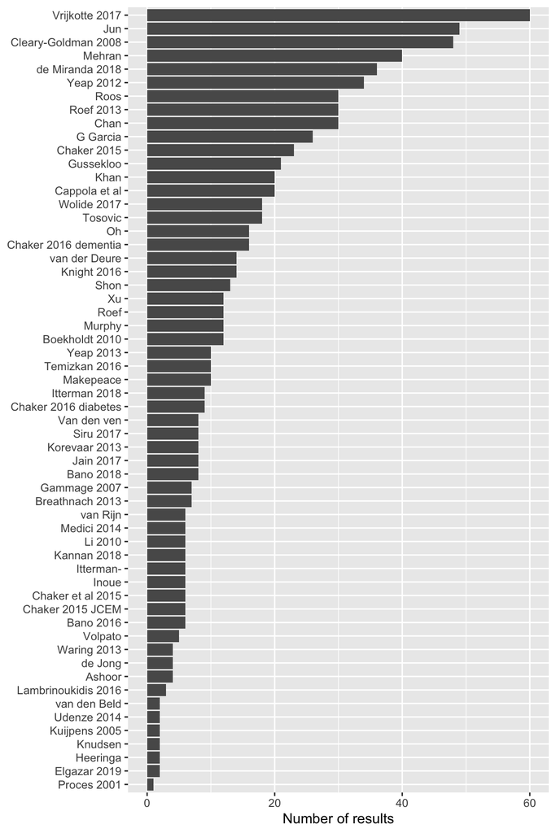

```r
TSH %>%
  count(Paper) %>%
  ggplot(aes(fct_reorder(Paper, n), n)) +
  geom_bar(stat = "identity") +
  coord_flip() +
  labs(x = NULL, y = "Number of results")
```

## 2.4 Continuous versus quantile

First rename to make easier

```r
TSH  <-
  TSH %>%
  rename(CvQ = `Continuous V quantile`)
```

```r
TSH %>%
  count(CvQ)
```

| CvQ | n |
| --- | --- |
| continous | 4 |
| continuous | 186 |
| Continuous | 377 |
| dichotomised | 6 |
| dichotomous | 9 |
| PERFORMANCE | 8 |
| PERFORMANCE CHANGE | 8 |
| quartiles | 63 |
| Quartiles | 33 |
| quintiles | 90 |

[output cut: 2 more lines]

Use the following set of mappings:

```r
TSH  <-
  TSH %>%
  mutate(
    CvQ = str_to_lower(CvQ),
    CvQ = case_when(
      str_detect(CvQ, "cont") ~ "continuous",
      str_detect(CvQ, "dicho") ~ "dichotomous",
      str_detect(CvQ, "quart") ~ "quartile",
      str_detect(CvQ, "performance") ~ "performance",
      TRUE ~ CvQ
    )
  )
```

```r
TSH %>%
  count(CvQ)
```

| CvQ | n |
| --- | --- |
| continuous | 567 |
| dichotomous | 15 |
| performance | 16 |
| quartile | 96 |
| quintiles | 96 |
| tertiles | 23 |

## 2.5 Condition

```r
TSH %>%
  count(`Condition Classification`)
```

| Condition Classification | n |
| --- | --- |
| AF | 27 |
| any | 10 |
| BP | 46 |
| breast | 30 |
| CAD | 39 |
| dementia | 68 |
| density | 40 |
| diabetes | 75 |
| foetal development | 3 |
| foetal growth | 68 |

[output cut: 17 more lines]

Some conditions, e.g., are present for more than one system.

```r
TSH %>%
  count(`Condition Classification`, System)
```

| Condition Classification | System | n |
| --- | --- | --- |
| AF | Cardiac | 27 |
| any | Cancer | 10 |
| BP | Metabolic | 31 |
| BP | Pregnancy | 15 |
| breast | Cancer | 30 |
| CAD | Cardiac | 39 |
| dementia | Dementia | 68 |
| density | Bone | 40 |
| diabetes | Metabolic | 64 |
| diabetes | Pregnancy | 11 |

[output cut: 24 more lines]

So we will create a condition that is of the form:

- `system : condition`

```r
TSH  <- TSH %>%
  mutate(
    condition = str_c(System, ":", `Condition Classification`)
  )
TSH %>%
  select(System, `Condition Classification`, condition)
```

| System | Condition Classification | condition |
| --- | --- | --- |
| Cardiac | AF | Cardiac:AF |
| Cardiac | AF | Cardiac:AF |
| Cardiac | CAD | Cardiac:CAD |
| Cardiac | CAD | Cardiac:CAD |
| Cardiac | other | Cardiac:other |
| Cardiac | other | Cardiac:other |
| Cardiac | other | Cardiac:other |
| Cardiac | other | Cardiac:other |
| Bone | fracture | Bone:fracture |
| Bone | fracture | Bone:fracture |

[output cut: 803 more lines]

## 2.6 System

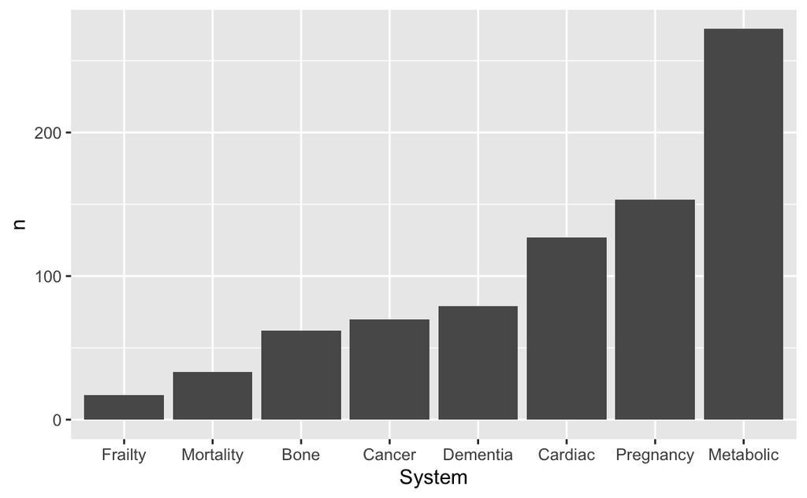

```r
TSH %>% count(System) %>%
  ggplot(aes(fct_reorder(System, n), n)) +
  geom_bar(stat = 'identity') +
  labs(x = "System")
```

## 2.7 FT4_N

```r
table(TSH$FT4_N)
```

```
##
##     1007     1011    10163    10206    10225     1025     1047     1070
##        1        4        2        2        6        2        1        2
##    10990      111     1137     1151     1177      125     1257     1275
##       48        6        2       14        2        1        1        8
##     1278     1338     1365     1429     1477      150     1572     1581
##        6        3        2        3        6        2       13       30
##      160     1602     1623  168/175     1741     1754     1804     1824
##        1        4        6        3        3        6        1        3
##     1853     1920     1947      200  200/200     2026      204     2041
##        7        3       30        1        1        6        3       30
##     2073     2078     2084     2136     2139      214     2144     2215
##        2       30        2        8        8       18        3        3
##     2223       23     2393     2557     2616     2673     2706     2738
##        1        1       40        6       15        3        3        1
```

[output cut: 22 more lines]

So some seem to have cases and controls. I will use the total as N, also not stated I will see to NA. Finally approx will be set to the value.

```r
pacman::p_load(tidyverse, testthat)

#' Convert numbers to a single number
#'
#' @param x string vector
#' @param check return a report or not
#'
#' @return numeric vector
#' @export
#'
#' @examples
clean_n  <- function(x, check = FALSE){
  origin_x  <- x
  # Get rid of not stated
  x[str_detect(x,"not stated")]  <- NA
  # Get rid of approx
  x  <- str_replace(x, " approx", "")
  # Get rid of cases and controls
  x  <- str_replace(x, "cases", "")
  x  <- str_replace(x, "controls", "")
  # Grab enteries of type case/control and add
  case_control  <- str_match(x, "(\\d+)/(\\d+)")
  total  <- as.numeric(case_control[, 2]) + as.numeric(case_control[, 3])
  index  <- which(!is.na(total))
  x[index]  <- total[index]
  x  <- as.numeric(x)
  # Compare
  if(check){
    tab  <-
      tibble(
        origin_x, x
      )  %>%
      filter(origin_x != x) %>%
      knitr::kable()
    return(tab)
  }
  return(x)
}

x  <- c("not stated", " approx 250", "10/12", "cases 24", "controls 33")
clean_n(x, check = TRUE)
expect_equal(clean_n(x), c(NA, 250, 22, 24, 33))
```

```r
clean_n(TSH$FT4_N, check = TRUE)
```

| origin_x | x |
| --- | --- |
| 629/644 | 1273 |
| 629/644 | 1273 |
| 168/175 | 343 |
| 461/469 | 930 |
| 327/329 | 656 |
| 302/315 | 617 |
| 629/644 | 1273 |
| 629/644 | 1273 |
| 168/175 | 343 |
| 461/469 | 930 |
| 327/329 | 656 |
| 302/315 | 617 |
| 629/644 | 1273 |
| 629/644 | 1273 |
| 168/175 | 343 |
| 461/469 | 930 |
| 327/329 | 656 |
| 302/315 | 617 |
| 865/848 | 1713 |
| 865/848 | 1713 |
| 865/848 | 1713 |
| 865/848 | 1713 |
| 865/848 | 1713 |
| 865/848 | 1713 |
| 741/82 | 823 |
| 741/82 | 823 |
| 741/82 | 823 |
| 741/82 | 823 |
| 741/82 | 823 |
| 741/82 | 823 |
| 741/82 | 823 |
| 4318/202 | 4520 |
| 4318/202 | 4520 |
| 4318/202 | 4520 |
| 4318/202 | 4520 |
| 488/333 | 821 |
| 488/333 | 821 |
| 200/200 | 400 |

```r
TSH  <-
  TSH %>%
  mutate(
  FT4_N = clean_n(FT4_N)
  )
```

```r
summary(TSH$FT4_N)
```

```
##    Min. 1st Qu.  Median    Mean 3rd Qu.    Max.
##      23    1273    2078    3246    3649   10990
```

## 2.8 FT4 method

```r
TSH %>%
  count(FT4_method)
```

| FT4_method | n |
| --- | --- |
| ?fixed effects | 6 |
| adjusted regression | 12 |
| Ancova | 1 |
| Anova | 6 |
| Anova/Tukey | 6 |
| Anova/Tukey/multiple log reg | 13 |
| Anova/X sq | 4 |
| Chi square | 1 |
| correlation analysis | 24 |
| Cox | 12 |

[output cut: 44 more lines]

```r
clean_levels(TSH$FT4_method, check = TRUE)
```

| x | x_refin |
| --- | --- |
| log.reg. | log reg |
| CoxPH | Cox PH |
| CoxPH | Cox PH |
| CoxPH | Cox PH |
| CoxPH | Cox PH |
| CoxPH | Cox PH |
| CoxPH | Cox PH |
| CoxPH | Cox PH |
| CoxPH | Cox PH |
| CoxPH | Cox PH |
| CoxPH | Cox PH |
| CoxPH | Cox PH |
| CoxPH | Cox PH |
| CoxPH | Cox PH |
| CoxPH | Cox PH |
| CoxPH | Cox PH |
| CoxPH | Cox PH |
| CoxPH* | Cox PH |
| CoxPH | Cox PH |
| CoxPH | Cox PH |
| CoxPH | Cox PH |
| CoxPH | Cox PH |
| CoxPH | Cox PH |
| CoxPH | Cox PH |

```r
TSH  <-
  TSH %>%
  mutate(
    FT4_method = clean_levels(FT4_method)
  )
```

## 2.9 FT4 sig

```r
TSH %>% count(FT4_Sig)
```

| FT4_Sig | n |
| --- | --- |
| N | 399 |
| N* | 8 |
| Y | 406 |

Convert `N*` to `N`.

```r
pacman::p_load(tidyverse, testthat)
#' Adds column that indicates if a significant results is inferred based on *
#'
#' @param x character string
#'
#' @return boolean vector
#' @export
#'
#' @examples
get_inferred  <- function(x){
  ifelse(str_detect(x, "\\*"), TRUE, FALSE)
}
expect_equal(get_inferred(c("N", "N*", "Y", "Y*")),
             c(FALSE, TRUE, FALSE, TRUE))
```

```r
TSH  <-
  TSH %>%
  mutate(FT4_inferred = get_inferred(FT4_Sig))
table(TSH$FT4_Sig, TSH$FT4_inferred)
```

```
##
##      FALSE TRUE
##   N    399    0
##   N*     0    8
##   Y    406    0
```

```r
TSH  <-
  TSH %>%
  mutate(FT4_Sig = str_replace_all(FT4_Sig, "\\*", ""))
table(TSH$FT4_Sig, TSH$FT4_inferred)
```

```
##
##     FALSE TRUE
##   N   399    8
##   Y   406    0
```

## 2.10 FT4 PV

Function to take PV column and convert to PV, OR CI, and count CI.

```r
pacman::p_load(tidyverse, testthat, readxl)

#' Extracts information from PV column
#'
#' @param x string vector
#' @param check will give enteries that did not parse
#'
#' @return data frame with pvalue, OR, and count.
#' @export
#'
#' @examples
clean_pv  <- function(x, check = FALSE){
  type  <- str_match(quo_name(enquo(x)), "\\$(.*)_PV")[, 2]
  origin_x  <- x
  # Set non stated to NA
  x[str_detect(x,"not stated")]  <- NA
  x[str_detect(x,"NS")]  <- NA
  # Get bounds on PV
  bounded  <- ifelse(str_detect(x, "<"), TRUE, FALSE)
  # Remove `<`
  x  <- str_replace(x, "<","")
  # Get pv. Uses side effect of as numeric - anything containing ( or ) get
  # convert to NA
  pv  <- as.numeric(x)
  ## Get count
  count  <- str_match(x, "(\\d+/\\d+)\\((.*)\\)")
  count_estimate  <- count[, 2]
  count_CI  <- count[, 3]
  x[!is.na(count_estimate)]  <- NA
  ## Get OR
  x  <- str_replace_all(x, " ", "")
  OR  <- str_match(x, "(.*)\\((.*)\\)")
  OR_estimate  <- as.numeric(OR[, 2])
  OR_CI  <- OR[, 3]
  ## Results
  df  <- tibble(
    origin_x  = origin_x,
    !! str_c(type, "_pv") := pv,
    !! str_c(type, "_bounded") := bounded,
    !! str_c(type, "_OR") := OR_estimate,
    !! str_c(type, "_ORCI") := OR_CI,
    !! str_c(type, "_count") := count_estimate,
    !! str_c(type, "_countCI") := count_CI
  )
  if(check){
    index  <- which(apply(df, 1, function(x){sum(is.na(x))}) > 4)
    tmp  <- df[index, ]
    tmp  <- tmp[!is.na(tmp[,1]),]
    tmp  <- tmp[!str_detect(tmp$origin_x, "not stated"),]
    tmp  <- tmp[!str_detect(tmp$origin_x, "NS"),]
    return(tmp)
  }
  return(df)
}
df  <- tibble(
  x_PV = c("0.001", "<0.001", "1.1(0.9-1.2)",
           "not stated", "11/100(1-2)", "1(0.9-1.2)", "NS")
  )
results  <- clean_pv(df$x_PV)
results
expect_equal(results$x_pv, c(0.001, 0.001, NA, NA, NA, NA, NA))
expect_equal(results$x_bounded, c(F, T, F, NA, F, F, NA))
expect_equal(results$x_OR, c(NA, NA, 1.1, NA, NA, 1, NA))
expect_equal(results$x_ORCI, c(NA, NA, "0.9-1.2", NA, NA, "0.9-1.2", NA))
expect_equal(results$x_count, c(NA, NA, NA, NA, "11/100", NA, NA))
expect_equal(results$x_countCI, c(NA, NA, NA, NA, "1-2", NA, NA))
```

```r
clean_pv(TSH$FT4_PV, check = TRUE)
```

| origin_x | FT4_pv | FT4_bounded | FT4_OR | FT4_ORCI | FT4_count | FT4_countCI |
| --- | --- | --- | --- | --- | --- | --- |

```r
pv  <- clean_pv(TSH$FT4_PV)
pv  <- pv %>% select(-origin_x)
pv
```

| FT4_pv | FT4_bounded | FT4_OR | FT4_ORCI | FT4_count | FT4_countCI |
| --- | --- | --- | --- | --- | --- |
| 0.0010 | TRUE | NA | NA | NA | NA |
| 0.0200 | FALSE | NA | NA | NA | NA |
| 0.1300 | FALSE | NA | NA | NA | NA |
| 0.2800 | FALSE | NA | NA | NA | NA |
| 0.0040 | FALSE | NA | NA | NA | NA |
| 0.0300 | FALSE | NA | NA | NA | NA |
| 0.0080 | FALSE | NA | NA | NA | NA |
| 0.0200 | FALSE | NA | NA | NA | NA |
| 0.7900 | FALSE | NA | NA | NA | NA |
| 0.5600 | FALSE | NA | NA | NA | NA |

[output cut: 803 more lines]

```r
TSH  <-
  TSH %>%
  bind_cols(pv)
```

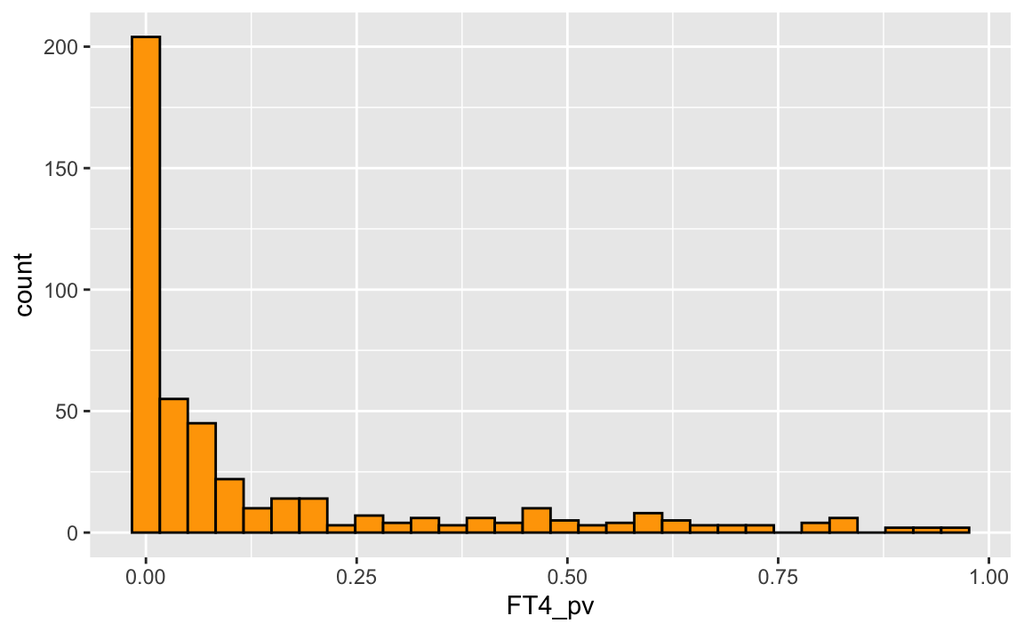

```r
TSH %>%
  ggplot(aes(FT4_pv)) + geom_histogram(col = "black", fill = "orange")
```

## 2.11 FT4_cov

```r
clean_levels(TSH$FT4_cov, check = TRUE)
```

| x | x_refin |
| --- | --- |
| age, sex | age,sex |
| age, sex | age,sex |
| age, sex | age,sex |
| age, sex | age,sex |
| age, sex | age,sex |
| age, sex | age,sex |
| age BMI smoking | age,smoking,BMI |
| age BMI smoking | age,smoking,BMI |
| age BMI smoking | age,smoking,BMI |
| age BMI smoking | age,smoking,BMI |
| age BMI smoking | age,smoking,BMI |
| age BMI smoking | age,smoking,BMI |
| Crude | crude |
| age,sex,smoking | age,sex, smoking |
| age,sex,smoking | age,sex, smoking |
| age,sex,smoking | age,sex, smoking |
| age,sex,smoking | age,sex, smoking |
| age,sex,smoking | age,sex, smoking |
| age,sex,smoking | age,sex, smoking |
| age,sex,smoking | age,sex, smoking |
| age,sex,smoking | age,sex, smoking |
| age,sex,smoking | age,sex, smoking |
| age,sex,smoking | age,sex, smoking |
| age,sex,smoking | age,sex, smoking |
| age,sex,interaction | age,sex and interaction |
| age,sex BMI | age,sex,BMI |
| age,sex BMI | age,sex,BMI |
| age,sex BMI | age,sex,BMI |
| age,sex, smokingplus BMI | age,sex, smoking plus BMI |
| age sex cohort | age,sex,cohort |
| age sex cohort | age,sex,cohort |
| age sex cohort | age,sex,cohort |
| age sex cohort | age,sex,cohort |

```r
TSH  <-
  TSH %>%
  mutate(
    FT4_cov = clean_levels(FT4_cov)
  )
```

## 2.12 FT4_sophistication

```r
TSH %>% count(FT4_Sophistication)
```

| FT4_Sophistication | n |
| --- | --- |
| Crude | 206 |
| High | 128 |
| Low | 139 |
| Medium | 340 |

```r
TSH %>% filter(is.na(FT4_Sophistication))
```

| hyper/hypo | Paper | CvQ | Condition and restrictions on cohorts | Condition Classification | System | FT4_N | FT4_method | FT4_Sig | FT4_PV | FT4_Sophistication | FT4_cov | TSH_N | TSH_method | TSH_Sig | TSH_PV | TSH_Sophistication | TSH_cov | T3_N | T3_method | T3_Sig | T3_PV | T3_Sophistication | T3_cov | T3 - Free or Total | Include? | NOS score | TSH incong | cross-section | abstract score | … |
| --- | --- | --- | --- | --- | --- | --- | --- | --- | --- | --- | --- | --- | --- | --- | --- | --- | --- | --- | --- | --- | --- | --- | --- | --- | --- | --- | --- | --- | --- | --- |

## 2.13 TSH_N

```r
clean_n(TSH$TSH_N, check = TRUE)
```

| origin_x | x |
| --- | --- |
| 628/644 | 1272 |
| 628/644 | 1272 |
| 169/175 | 344 |
| 459/469 | 928 |
| 326/328 | 654 |
| 628/644 | 1272 |
| 628/644 | 1272 |
| 630/646 | 1276 |
| 169/175 | 344 |
| 459/469 | 928 |
| 326/328 | 654 |
| 302/316 | 618 |
| 628/644 | 1272 |
| 628/644 | 1272 |
| 169/175 | 344 |
| 459/469 | 928 |
| 326/328 | 654 |
| 302/316 | 618 |
| 2700 approx | 2700 |
| 2700 approx | 2700 |
| 2700 approx | 2700 |
| 2700 approx | 2700 |
| 2700 approx | 2700 |
| 2700 approx | 2700 |
| 2700 approx | 2700 |
| 2700 approx | 2700 |
| 2700 approx | 2700 |
| 2700 approx | 2700 |
| 892/894 | 1786 |
| 900/894 | 1794 |
| 892/894 | 1786 |
| 900/894 | 1794 |
| 892/894 | 1786 |
| 900/894 | 1794 |
| 741/133 | 874 |
| 741/133 | 874 |
| 741/133 | 874 |
| 741/133 | 874 |
| 741/133 | 874 |
| 741/133 | 874 |
| 741/133 | 874 |
| 488/333 | 821 |
| 488/333 | 821 |
| 200/200 | 400 |

```r
TSH  <- TSH %>%
  mutate(TSH_N = clean_n(TSH_N))
```

## 2.14 TSH_method

```r
clean_levels(TSH$TSH_method, check = TRUE)
```

| x | x_refin |
| --- | --- |
| log.reg. | log reg |
| CoxPH | Cox PH |
| CoxPH | Cox PH |
| CoxPH | Cox PH |
| CoxPH | Cox PH |
| CoxPH | Cox PH |
| CoxPH | Cox PH |
| CoxPH | Cox PH |
| CoxPH | Cox PH |
| CoxPH | Cox PH |
| CoxPH | Cox PH |
| CoxPH | Cox PH |
| CoxPH | Cox PH |
| CoxPH | Cox PH |
| CoxPH | Cox PH |
| CoxPH | Cox PH |
| CoxPH | Cox PH |
| CoxPH | Cox PH |
| CoxPH | Cox PH |
| CoxPH | Cox PH |
| CoxPH | Cox PH |
| CoxPH | Cox PH |
| Cox PH * | Cox PH |
| CoxPH | Cox PH |
| CoxPH | Cox PH |
| CoxPH | Cox PH |
| CoxPH | Cox PH |
| CoxPH | Cox PH |
| CoxPH | Cox PH |

```r
TSH  <-
  TSH %>%
  mutate(TSH_method = clean_levels(TSH_method))
```

## 2.15 TSH_sig

```r
TSH %>%
  count(TSH_Sig)
```

| TSH_Sig | n |
| --- | --- |
| N | 611 |
| N* | 19 |
| Y | 182 |
| Y* | 1 |

```r
TSH  <-
  TSH %>%
  mutate(TSH_inferred = get_inferred(TSH_Sig))
table(TSH$TSH_Sig, TSH$TSH_inferred)
```

```
##
##      FALSE TRUE
##   N    611    0
##   N*     0   19
##   Y    182    0
##   Y*     0    1
```

```r
TSH  <-
  TSH %>%
  mutate(TSH_Sig = str_replace_all(TSH_Sig, "\\*", ""))
table(TSH$TSH_Sig, TSH$TSH_inferred)
```

```
##
##     FALSE TRUE
##   N   611   19
##   Y   182    1
```

## 2.16 TSH PV

```r
clean_pv(TSH$TSH_PV, check = TRUE)
```

| origin_x | TSH_pv | TSH_bounded | TSH_OR | TSH_ORCI | TSH_count | TSH_countCI |
| --- | --- | --- | --- | --- | --- | --- |

```r
pv  <- clean_pv(TSH$TSH_PV)
pv  <- pv %>% select(-origin_x)
pv
```

| TSH_pv | TSH_bounded | TSH_OR | TSH_ORCI | TSH_count | TSH_countCI |
| --- | --- | --- | --- | --- | --- |
| 0.0900 | FALSE | NA | NA | NA | NA |
| 0.1200 | FALSE | NA | NA | NA | NA |
| 0.2000 | FALSE | NA | NA | NA | NA |
| 0.1500 | FALSE | NA | NA | NA | NA |
| 0.1700 | FALSE | NA | NA | NA | NA |
| 0.0900 | FALSE | NA | NA | NA | NA |
| 0.0500 | FALSE | NA | NA | NA | NA |
| 0.0400 | FALSE | NA | NA | NA | NA |
| 0.2000 | FALSE | NA | NA | NA | NA |
| 0.2600 | FALSE | NA | NA | NA | NA |

[output cut: 803 more lines]

```r
TSH  <-
  TSH %>%
  bind_cols(pv)
```

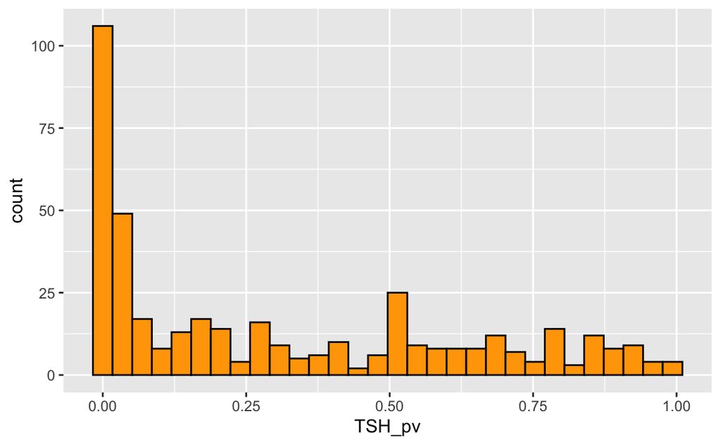

```r
TSH %>%
  ggplot(aes(TSH_pv)) + geom_histogram(col = "black", fill = "orange")
```

## 2.17 TSH cov

```r
clean_levels(TSH$TSH_cov, check = TRUE)
```

| x | x_refin |
| --- | --- |
| age, sex | age,sex |
| age, sex | age,sex |
| age, sex | age,sex |
| age, sex | age,sex |
| age, sex | age,sex |
| age, sex | age,sex |
| age BMI smoking | age,smoking,BMI |
| age BMI smoking | age,smoking,BMI |
| age BMI smoking | age,smoking,BMI |
| age BMI smoking | age,smoking,BMI |
| age BMI smoking | age,smoking,BMI |
| age BMI smoking | age,smoking,BMI |
| Crude | crude |
| age,sex,smoking | age,sex, smoking |
| age,sex,smoking | age,sex, smoking |
| age,sex,smoking | age,sex, smoking |
| age,sex,smoking | age,sex, smoking |
| age,sex,smoking | age,sex, smoking |
| age,sex,smoking | age,sex, smoking |
| age,sex,smoking | age,sex, smoking |
| age,sex,smoking | age,sex, smoking |
| age,sex,smoking | age,sex, smoking |
| age,sex,smoking | age,sex, smoking |
| age,sex,smoking | age,sex, smoking |
| age,sex,interaction | age,sex and interaction |
| age,sex BMI | age,sex,BMI |
| age,sex BMI | age,sex,BMI |
| age,sex BMI | age,sex,BMI |
| age,sex, smokingplus BMI | age,sex, smoking plus BMI |
| age sex cohort | age,sex,cohort |
| age sex cohort | age,sex,cohort |
| age sex cohort | age,sex,cohort |
| age sex cohort | age,sex,cohort |

```r
TSH  <-
  TSH %>%
  mutate(
    TSH_cov = clean_levels(TSH_cov)
  )
```

## 2.18 TSH_sophistication

```r
TSH %>% count(TSH_Sophistication)
```

| TSH_Sophistication | n |
| --- | --- |
| Crude | 206 |
| High | 128 |
| Low | 139 |
| Medium | 340 |

```r
TSH %>% filter(is.na(TSH_Sophistication))
```

| hyper/hypo | Paper | CvQ | Condition and restrictions on cohorts | Condition Classification | System | FT4_N | FT4_method | FT4_Sig | FT4_PV | FT4_Sophistication | FT4_cov | TSH_N | TSH_method | TSH_Sig | TSH_PV | TSH_Sophistication | TSH_cov | T3_N | T3_method | T3_Sig | T3_PV | T3_Sophistication | T3_cov | T3 - Free or Total | Include? | NOS score | TSH incong | cross-section | abstract score | … |
| --- | --- | --- | --- | --- | --- | --- | --- | --- | --- | --- | --- | --- | --- | --- | --- | --- | --- | --- | --- | --- | --- | --- | --- | --- | --- | --- | --- | --- | --- | --- |

## 2.19 T3 N

```r
clean_n(TSH$T3_N, check = TRUE)
```

| origin_x | x |
| --- | --- |
| 629/644 | 1273 |
| 629/644 | 1273 |
| 168/175 | 343 |
| 461/469 | 930 |
| 327/329 | 656 |
| 302/315 | 617 |
| 629/644 | 1273 |
| 629/644 | 1273 |
| 168/175 | 343 |
| 461/469 | 930 |
| 327/329 | 656 |
| 302/315 | 617 |
| 629/644 | 1273 |
| 629/644 | 1273 |
| 168/175 | 343 |
| 461/469 | 930 |
| 327/329 | 656 |
| 302/315 | 617 |
| 200/200 | 400 |

```r
TSH  <-
  TSH %>%
  mutate(
    T3_N = clean_n(T3_N)
  )
```

## 2.20 T3 method

```r
clean_levels(TSH$T3_method, check = TRUE)
```

| x | x_refin |
| --- | --- |
| Cox PH* | Cox PH |
| CoxPH | Cox PH |
| CoxPH | Cox PH |
| CoxPH | Cox PH |
| CoxPH | Cox PH |
| CoxPH | Cox PH |
| CoxPH | Cox PH |

```r
TSH  <-
  TSH %>%
  mutate(
    T3_method = clean_levels(T3_method)
  )
```

## 2.21 T3 sig

```r
TSH %>%
  count(T3_Sig)
```

| T3_Sig | n |
| --- | --- |
| N | 118 |
| N* | 2 |
| Y | 134 |
| NA | 559 |

```r
TSH %>%
  count(T3_Sig)
```

| T3_Sig | n |
| --- | --- |
| N | 118 |
| N* | 2 |
| Y | 134 |
| NA | 559 |

```r
TSH  <-
  TSH %>%
  mutate(T3_inferred = get_inferred(T3_Sig))
table(TSH$T3_Sig, TSH$T3_inferred)
```

```
##
##      FALSE TRUE
##   N    118    0
##   N*     0    2
##   Y    134    0
```

```r
TSH  <-
  TSH %>%
  mutate(T3_Sig = str_replace_all(T3_Sig, "\\*", ""))
table(TSH$T3_Sig, TSH$T3_inferred)
```

```
##
##     FALSE TRUE
##   N   118    2
##   Y   134    0
```

## 2.22 T3 PV

```r
clean_pv(TSH$T3_PV, check = TRUE)
```

| origin_x | T3_pv | T3_bounded | T3_OR | T3_ORCI | T3_count | T3_countCI |
| --- | --- | --- | --- | --- | --- | --- |

```r
pv  <- clean_pv(TSH$T3_PV)
pv  <- pv %>% select(-origin_x)
pv
```

| T3_pv | T3_bounded | T3_OR | T3_ORCI | T3_count | T3_countCI |
| --- | --- | --- | --- | --- | --- |
| 0.4000 | FALSE | NA | NA | NA | NA |
| 0.2400 | FALSE | NA | NA | NA | NA |
| 0.0900 | FALSE | NA | NA | NA | NA |
| 0.3100 | FALSE | NA | NA | NA | NA |
| 0.5400 | FALSE | NA | NA | NA | NA |
| 0.7700 | FALSE | NA | NA | NA | NA |
| 0.4300 | FALSE | NA | NA | NA | NA |
| 0.7800 | FALSE | NA | NA | NA | NA |
| 0.7300 | FALSE | NA | NA | NA | NA |
| 0.8600 | FALSE | NA | NA | NA | NA |

[output cut: 803 more lines]

```r
TSH  <-
  TSH %>%
  bind_cols(pv)
```

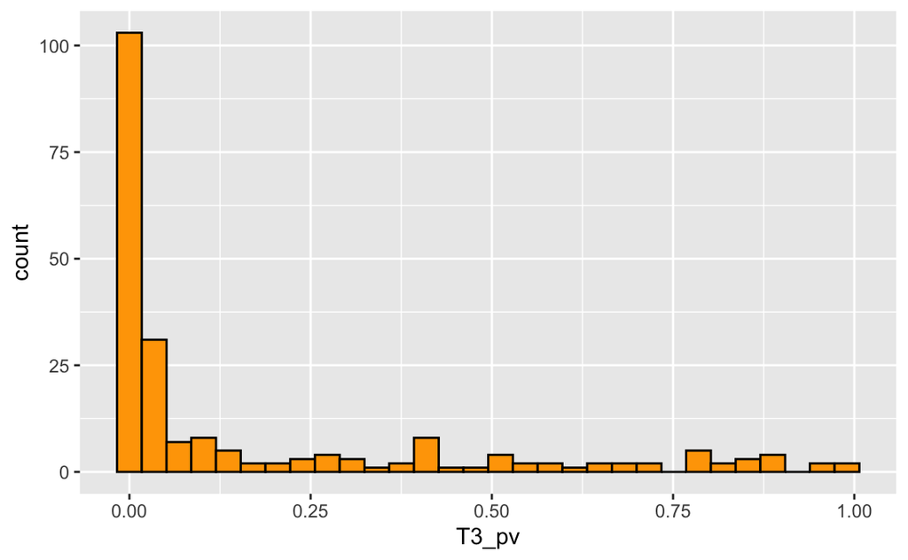

```r
TSH %>%
  ggplot(aes(T3_pv)) + geom_histogram(col = "black", fill = "orange")
```

## 2.23 T3 cov

```r
clean_levels(TSH$T3_cov, check = TRUE)
```

| x | x_refin |
| --- | --- |
| Crude | crude |

```r
TSH  <-
  TSH %>%
  mutate(
    T3_cov = clean_levels(T3_cov)
  )
```

## 2.24 T3_sophistication

```r
TSH %>% count(T3_Sophistication)
```

| T3_Sophistication | n |
| --- | --- |
| Crude | 103 |
| High | 45 |
| Low | 13 |
| Medium | 93 |
| NA | 559 |

## 2.25 Total T3

```r
TSH %>% count(`T3 - Free or Total`)
```

| T3 - Free or Total | n |
| --- | --- |
| Free | 183 |
| Total | 71 |
| NA | 559 |

Rename

```r
TSH  <-
  TSH %>%
  rename(
    T3_total = `T3 - Free or Total`
  )
```

```r
TSH %>% count(T3_total)
```

| T3_total | n |
| --- | --- |
| Free | 183 |
| Total | 71 |
| NA | 559 |

## 2.26 Remove original PV columns

```r
TSH  <-
  TSH %>%
  select(-FT4_PV, -TSH_PV, -T3_PV)
```

## 2.27 Add cohort column

```r
#' add cohorts to papers
#'
#' @param n is the observed number of subjects
#'
#' @return factor for each unique size
#' @export
#'
#' @examples
add_cohort  <- function(n){
  m  <- length(unique(n))
  cohorts  <- str_c("C", 1:m)
  cohorts  <- as.character(factor(n, labels = cohorts))
  return(cohorts)
}
```

```r
TSH  <-
  TSH %>% group_by(Paper) %>%
  mutate(cohort = add_cohort(FT4_N))
```

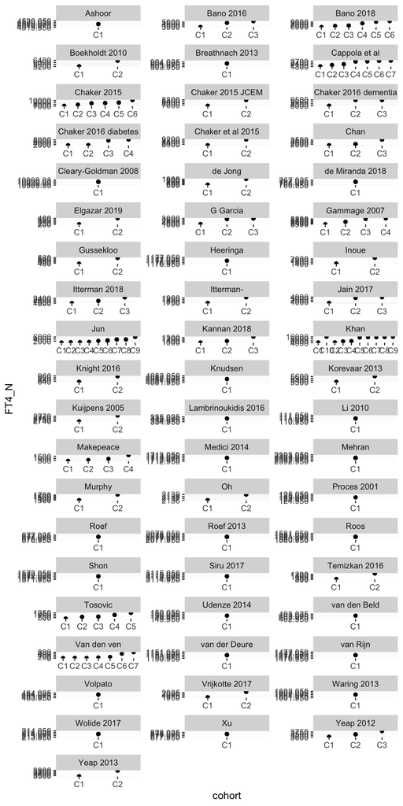

```r
TSH %>% ggplot(aes(cohort, FT4_N)) + geom_point() +
  facet_wrap(~Paper, scales = "free", ncol = 3)
```

## 2.28 Check hyper / hypo

```r
TSH %>%
  ungroup() %>%
  count(`hyper/hypo`)
```

| hyper/hypo | n |
| --- | --- |
| hyper | 328 |
| Hyper | 30 |
| hyper/hypo | 60 |
| hypo | 361 |
| Hypo | 14 |
| indeterminate | 20 |

```r
TSH  <- TSH %>%
  mutate(`hyper/hypo` = str_to_title(`hyper/hypo`))
```

```r
TSH %>%
  ungroup() %>%
  count(`hyper/hypo`)
```

| hyper/hypo | n |
| --- | --- |
| Hyper | 358 |
| Hyper/Hypo | 60 |
| Hypo | 375 |
| Indeterminate | 20 |

## 2.29 Devil advocate sampling

For each paper, we select one analysis from the following treatments:

- low size, low number of covariates
- low size, large number of covariates
- large size, low number of covariates
- large size, large number of covariates

Samples first for size and then for method. May get repeated analysis, but ensures an analysis for each treatment level.

```r
set.seed(2019)
TSH  <-
  TSH %>%
  group_by(Paper) %>%
  mutate(
    min_size_min_method = get_DA(
      FT4_N, FT4_cov, size = 'min', method = 'min'),
    min_size_max_method = get_DA(
      FT4_N, FT4_cov, size = 'min', method = 'max'),
    max_size_min_method = get_DA(
      FT4_N, FT4_cov, size = 'max', method = 'min'),
    max_size_max_method = get_DA(
      FT4_N, FT4_cov, size = 'max', method = 'max')
  )
```

So there should be one for each paper.

```r
length(unique(TSH$Paper))
```

```
## [1] 58
```

```r
TSH %>% filter(min_size_min_method)
```

| hyper/hypo | Paper | CvQ | Condition and restrictions on cohorts | Condition Classification | System | FT4_N | FT4_method | FT4_Sig | FT4_Sophistication | FT4_cov | TSH_N | TSH_method | TSH_Sig | TSH_Sophistication | TSH_cov | T3_N | T3_method | T3_Sig | T3_Sophistication | T3_cov | T3_total | Include? | NOS score | TSH incong | cross-section | abstract score | ID | condition | FT4_inferred | … |
| --- | --- | --- | --- | --- | --- | --- | --- | --- | --- | --- | --- | --- | --- | --- | --- | --- | --- | --- | --- | --- | --- | --- | --- | --- | --- | --- | --- | --- | --- | --- |
| Hyper | Cappola et al | quartile | Dementia | dementia | Dementia | 1824 | Cox PH | N | Crude | not stated | 1824 | Cox PH | Y | Crude | not stated | NA | NA | NA | NA | NA | NA | 1 | NA | 0 | N | NA | 20 | Dementia:dementia | FALSE | … |
| Hyper | Chaker et al 2015 | continuous | AF prevalent normal TSH/FT4, excluding thyroid medication users | AF | Cardiac | 7740 | log regression | Y | Low | age,sex | 7740 | log regression | N | Low | age,sex | NA | NA | NA | NA | NA | NA | 0 | NA | 0 | Y | NA | 23 | Cardiac:AF | FALSE | … |
| Hyper | Chaker 2015 JCEM | continuous | AF incident normal FT4/TSH, excluding thyroid medication | AF | Cardiac | 7409 | Cox PH | Y | Low | age,sex | 7409 | Cox PH | N | Low | age,sex | NA | NA | NA | NA | NA | NA | 1 | NA | 0 | N | NA | 29 | Cardiac:AF | FALSE | … |
| Hyper | Gammage 2007 | continuous | prevalent AF, normal FT4/stringently normal TSH | AF | Cardiac | 5285 | log reg | Y | Medium | smoking,diabetes,hypertension, heart failure, IHD | 5285 | log reg | N | Medium | smoking,diabetes,hypertension, heart failure, IHD | NA | NA | NA | NA | NA | NA | 0 | NA | 0 | Y | NA | 39 | Cardiac:AF | FALSE | … |
| Hyper | Heeringa | continuous | incident AF | AF | Cardiac | 1177 | Cox PH | N | Low | age,sex | 1426 | Cox PH | Y | Low | age,sex | NA | NA | NA | NA | NA | NA | 1 | 8 | 0 | N | 4 | 40 | Cardiac:AF | FALSE | … |
| Hyper | Chaker 2015 | continuous | SCD excluding abnormal FT4,thyroid medication, heart failure and cor heart disease plus heart rate variability | mortality | Cardiac | 7131 | Cox PH | Y | Medium | age,sex | 7164 | Cox PH | N | Medium | age,sex | NA | NA | NA | NA | NA | NA | 1 | NA | 0 | N | NA | 63 | Cardiac:mortality | FALSE | … |
| Hyper | van Rijn | continuous | low bone density | density | Bone | 1477 | Anova/X sq | Y | Crude | crude | 1477 | Anova/X sq | N | Crude | crude | NA | NA | NA | NA | NA | NA | 0 | 9 | 0 | Y | 1 | 65 | Bone:density | FALSE | … |
| Hyper | van der Deure | continuous | cross sectional area | density | Bone | 1151 | log reg | Y | Low | age,sex | 1151 | log reg | Y | Low | age,sex | NA | NA | NA | NA | NA | NA | 0 | NA | 0 | Y | NA | 77 | Bone:density | FALSE | … |
| Hyper | Murphy | continuous | incident non-vertebral fracture | fracture | Bone | 1278 | Cox PH/log reg | Y | Crude | crude | 1278 | Cox PH/log reg | N | Crude | crude | 1278 | Cox PH/log reg | Y | Crude | crude | Free | 1 | NA | 0 | N | NA | 95 | Bone:fracture | FALSE | … |
| Hyper | Roef | continuous | body BMC | density | Bone | 677 | linear mixed effects modelling | N | Medium | age,height,weight,smoking | 677 | linear mixed effects modelling | N | Medium | age,height,weight,smoking | 677 | linear mixed effects modelling | Y | Medium | age,height,weight,smoking | Free | 0 | NA | 0 | Y | NA | 102 | Bone:density | FALSE | … |

[output cut: 48 more lines]

```r
TSH %>% filter(min_size_max_method)
```

| hyper/hypo | Paper | CvQ | Condition and restrictions on cohorts | Condition Classification | System | FT4_N | FT4_method | FT4_Sig | FT4_Sophistication | FT4_cov | TSH_N | TSH_method | TSH_Sig | TSH_Sophistication | TSH_cov | T3_N | T3_method | T3_Sig | T3_Sophistication | T3_cov | T3_total | Include? | NOS score | TSH incong | cross-section | abstract score | ID | condition | FT4_inferred | … |
| --- | --- | --- | --- | --- | --- | --- | --- | --- | --- | --- | --- | --- | --- | --- | --- | --- | --- | --- | --- | --- | --- | --- | --- | --- | --- | --- | --- | --- | --- | --- |
| Hyper | Cappola et al | continuous | Dementia | dementia | Dementia | 1824 | Cox PH | N | High | Age, sex, race, initiation of Thyroid Hormone replacement and BMI, hypertension, diabetes, current smoking, any alcohol, total cholesterol, stroke, claudication and apoe4 genotype | 1824 | Cox PH | N | High | Age, sex, race, initiation of Thyroid Hormone replacement and BMI, hypertension, diabetes, current smoking, LDL cholesterol, lipid-lowering medication and C-reactive protein | 1824 | Cox PH | N | High | Age, sex, race, initiation of Thyroid Hormone replacement and BMI, hypertension, diabetes, current smoking, LDL cholesterol, lipid-lowering medication and C-reactive protein | Total | 1 | NA | 0 | N | NA | 12 | Dementia:dementia | FALSE | … |
| Hyper | Chaker et al 2015 | continuous | AF prevalent normal TSH/FT4, excluding thyroid medication users | AF | Cardiac | 7740 | log regression | Y | Medium | age,sex, BMI, smoking, hypertension, diabetes,cholesterol | 7740 | log regression | N | Medium | age,sex, BMI, smoking, hypertension, diabetes,cholesterol | NA | NA | NA | NA | NA | NA | 0 | NA | 0 | Y | NA | 24 | Cardiac:AF | FALSE | … |
| Hyper | Chaker 2015 JCEM | quartile | AF incident, normal FT4/TSH excluding thyroid medication | AF | Cardiac | 7409 | Cox PH | Y | Medium | age,sex, BMI, smoking, hypertension, diabetes,cholesterol | 7409 | Cox PH | N | Medium | age,sex, BMI, smoking, hypertension, diabetes,cholesterol | NA | NA | NA | NA | NA | NA | 1 | NA | 0 | N | NA | 32 | Cardiac:AF | FALSE | … |
| Hyper | Gammage 2007 | continuous | prevalent AF, normal FT4/stringently normal TSH | AF | Cardiac | 5285 | log reg | Y | Medium | smoking,diabetes,hypertension, heart failure, IHD | 5285 | log reg | N | Medium | smoking,diabetes,hypertension, heart failure, IHD | NA | NA | NA | NA | NA | NA | 0 | NA | 0 | Y | NA | 39 | Cardiac:AF | FALSE | … |
| Hyper | Heeringa | continuous | incident AF | AF | Cardiac | 1177 | Cox PH | N | Medium | age,sex,smoking,BMI,BP, diabetse, cholesterol, time of sample | 1426 | Cox PH | Y | Medium | age,sex,smoking,BMI,BP, diabetse, cholesterol, time of sample | NA | NA | NA | NA | NA | NA | 1 | NA | 0 | N | NA | 41 | Cardiac:AF | FALSE | … |
| Hyper | Chaker 2015 | continuous | SCD excluding abnormal FT4,thyroid medication, heart failure and cor heart disease plus heart rate variability | mortality | Cardiac | 7131 | Cox PH | Y | High | age,sex plus cohort.pulse,BP,diab,BMI,smoking | 7146 | Cox PH | N | High | age,sex plus cohort.pulse,BP,diab,BMI,smoking | NA | NA | NA | NA | NA | NA | 1 | NA | 0 | N | NA | 64 | Cardiac:mortality | FALSE | … |
| Hyper | van Rijn | continuous | low bone density | density | Bone | 1477 | log reg | Y | Medium | age,smoking, BMI, alcohol | 1477 | log reg | N | Medium | age,smoking, BMI, alcohol | NA | NA | NA | NA | NA | NA | 0 | NA | 0 | Y | NA | 69 | Bone:density | FALSE | … |
| Hyper | van der Deure | continuous | buckling ratio | density | Bone | 1151 | log reg | Y | Medium | age,sex,BMI | 1151 | log reg | N | Medium | age,sex,BMI | NA | NA | NA | NA | NA | NA | 0 | NA | 0 | Y | NA | 84 | Bone:density | FALSE | … |
| Hyper | Murphy | continuous | incident non-vertebral fracture | fracture | Bone | 1278 | Cox PH/log reg | Y | Medium | age,BMI and lumbar BD | 1278 | Cox PH/log reg | Y | Medium | age,BMI and lumbar BD | 1278 | Cox PH/log reg | Y | Medium | age,BMI and lumbar BD | Free | 1 | NA | 0 | N | NA | 96 | Bone:fracture | FALSE | … |
| Hyper | Roef | continuous | hip BMC | density | Bone | 677 | linear mixed effects modelling | N | Medium | age,height,weight,smoking | 677 | linear mixed effects modelling | N | Medium | age,height,weight,smoking | 677 | linear mixed effects modelling | Y | Medium | age,height,weight,smoking | Free | 0 | NA | 0 | Y | NA | 101 | Bone:density | FALSE | … |

[output cut: 48 more lines]

```r
TSH %>% filter(max_size_min_method)
```

| hyper/hypo | Paper | CvQ | Condition and restrictions on cohorts | Condition Classification | System | FT4_N | FT4_method | FT4_Sig | FT4_Sophistication | FT4_cov | TSH_N | TSH_method | TSH_Sig | TSH_Sophistication | TSH_cov | T3_N | T3_method | T3_Sig | T3_Sophistication | T3_cov | T3_total | Include? | NOS score | TSH incong | cross-section | abstract score | ID | condition | FT4_inferred | … |
| --- | --- | --- | --- | --- | --- | --- | --- | --- | --- | --- | --- | --- | --- | --- | --- | --- | --- | --- | --- | --- | --- | --- | --- | --- | --- | --- | --- | --- | --- | --- |
| Hyper | Cappola et al | quartile | Mortality | mortality | Mortality | 2843 | Cox PH | Y | Crude | not stated | 2843 | Cox PH | N | Crude | not stated | NA | NA | NA | NA | NA | NA | 1 | NA | 0 | N | NA | 18 | Mortality:mortality | FALSE | … |
| Hyper | Chaker et al 2015 | continuous | AF prevalent | AF | Cardiac | 9160 | log regression | Y | Low | age,sex | 9161 | log regression | N | Low | age,sex | NA | NA | NA | NA | NA | NA | 0 | 9 | 0 | Y | 1 | 21 | Cardiac:AF | FALSE | … |
| Hyper | Chaker 2015 JCEM | continuous | AF incident | AF | Cardiac | 8734 | Cox PH | Y | Low | age,sex | 8734 | Cox PH | N | Low | age,sex | NA | NA | NA | NA | NA | NA | 1 | NA | 0 | N | NA | 27 | Cardiac:AF | FALSE | … |
| Hyper | Gammage 2007 | continuous | prevalent AF | AF | Cardiac | 5860 | crude | Y | Crude | not stated | 5806 | crude | N | Crude | not stated | NA | NA | NA | NA | NA | NA | 0 | 9 | 0 | Y | 1 | 33 | Cardiac:AF | FALSE | … |
| Hyper | Heeringa | continuous | incident AF | AF | Cardiac | 1177 | Cox PH | N | Low | age,sex | 1426 | Cox PH | Y | Low | age,sex | NA | NA | NA | NA | NA | NA | 1 | 8 | 0 | N | 4 | 40 | Cardiac:AF | FALSE | … |
| Hyper | Chaker 2015 | continuous | sudden cardiac death | mortality | Cardiac | 10225 | Cox PH | Y | Low | age,sex | 10314 | Cox PH | N | Low | age,sex | NA | NA | NA | NA | NA | NA | 1 | 9 | 0 | N | 1 | 42 | Cardiac:mortality | FALSE | … |
| Hyper | van Rijn | quartile | low bone density | density | Bone | 1477 | Anova/X sq | Y | Crude | crude | 1477 | Anova/X sq | N | Crude | crude | NA | NA | NA | NA | NA | NA | 0 | NA | 0 | Y | NA | 66 | Bone:density | FALSE | … |
| Hyper | van der Deure | continuous | femoral neck | density | Bone | 1151 | log reg | Y | Low | age,sex | 1151 | log reg | N | Low | age,sex | NA | NA | NA | NA | NA | NA | 0 | NA | 0 | Y | NA | 73 | Bone:density | FALSE | … |
| Hyper | Murphy | continuous | lumbar spine entry | density | Bone | 1754 | Anova/Tukey | N | Medium | age,smoking,BMI | 1754 | Anova/Tukey | N | Medium | age,smoking,BMI | 1754 | Anova/Tukey | N | Medium | age BMI smoking | Free | 0 | 7 | 0 | Y | 3 | 85 | Bone:density | FALSE | … |
| Hyper | Roef | continuous | spine BMC | density | Bone | 677 | linear mixed effects modelling | N | Medium | age,height,weight,smoking | 677 | linear mixed effects modelling | N | Medium | age,height,weight,smoking | 677 | linear mixed effects modelling | Y | Medium | age,height,weight,smoking | Free | 0 | NA | 0 | Y | NA | 100 | Bone:density | FALSE | … |

[output cut: 48 more lines]

```r
TSH %>% filter(max_size_max_method)
```

| hyper/hypo | Paper | CvQ | Condition and restrictions on cohorts | Condition Classification | System | FT4_N | FT4_method | FT4_Sig | FT4_Sophistication | FT4_cov | TSH_N | TSH_method | TSH_Sig | TSH_Sophistication | TSH_cov | T3_N | T3_method | T3_Sig | T3_Sophistication | T3_cov | T3_total | Include? | NOS score | TSH incong | cross-section | abstract score | ID | condition | FT4_inferred | … |
| --- | --- | --- | --- | --- | --- | --- | --- | --- | --- | --- | --- | --- | --- | --- | --- | --- | --- | --- | --- | --- | --- | --- | --- | --- | --- | --- | --- | --- | --- | --- |
| Hyper | Cappola et al | continuous | Total Mortality | mortality | Mortality | 2843 | Cox PH | N | High | Age, sex, race, initiation of Thyroid Hormone replacement and BMI, hypertension, diabetes, current smoking,CHD, HF, stroke, claudication, depressioon score, creatinine and kcal of activity | 2843 | Cox PH | N | High | Age, sex, race, initiation of Thyroid Hormone replacement and BMI, hypertension, diabetes, current smoking,CHD, HF, stroke, claudication, depressioon score, creatinine and kcal of activity | 2843 | Cox PH | N | High | Age, sex, race, initiation of Thyroid Hormone replacement and BMI, hypertension, diabetes, current smoking,CHD, HF, stroke, claudication, depressioon score, creatinine and kcal of activity | Total | 1 | NA | 0 | N | NA | 14 | Mortality:mortality | FALSE | … |
| Hyper | Chaker et al 2015 | continuous | AF prevalent | AF | Cardiac | 9160 | log regression | Y | Medium | age,sex, BMI, smoking, hypertension, diabetes,cholesterol | 9161 | log regression | N | Medium | age,sex, BMI, smoking, hypertension, diabetes,cholesterol | NA | NA | NA | NA | NA | NA | 0 | NA | 0 | Y | NA | 22 | Cardiac:AF | FALSE | … |
| Hyper | Chaker 2015 JCEM | continuous | AF incident | AF | Cardiac | 8734 | Cox PH | Y | Medium | age,sex, BMI, smoking, hypertension, diabetes,cholesterol | 8734 | Cox PH | N | Medium | age,sex, BMI, smoking, hypertension, diabetes,cholesterol | NA | NA | NA | NA | NA | NA | 1 | NA | 0 | N | NA | 28 | Cardiac:AF | FALSE | … |
| Hyper | Gammage 2007 | continuous | prevalent AF | AF | Cardiac | 5860 | log reg | Y | Medium | smoking,diabetes,hypertension, heart failure, IHD | 5806 | log reg | N | Medium | smoking,diabetes,hypertension, heart failure, IHD | NA | NA | NA | NA | NA | NA | 0 | NA | 0 | Y | NA | 34 | Cardiac:AF | FALSE | … |
| Hyper | Heeringa | continuous | incident AF | AF | Cardiac | 1177 | Cox PH | N | Medium | age,sex,smoking,BMI,BP, diabetse, cholesterol, time of sample | 1426 | Cox PH | Y | Medium | age,sex,smoking,BMI,BP, diabetse, cholesterol, time of sample | NA | NA | NA | NA | NA | NA | 1 | NA | 0 | N | NA | 41 | Cardiac:AF | FALSE | … |
| Hyper | Chaker 2015 | tertiles | sudden cardiac death | mortality | Cardiac | 10225 | Cox PH | Y | Medium | sex,age,cohort,pulse,hypertension,, chol, diabetes, BMI, smoking | 10314 | Cox PH | N | Medium | sex,age,cohort,pulse,hypertension,, chol, diabetes, BMI, smoking | NA | NA | NA | NA | NA | NA | 1 | NA | 0 | N | NA | 49 | Cardiac:mortality | FALSE | … |
| Hyper | van Rijn | continuous | low bone density | density | Bone | 1477 | log reg | Y | Medium | age,smoking, BMI, alcohol | 1477 | log reg | N | Medium | age,smoking, BMI, alcohol | NA | NA | NA | NA | NA | NA | 0 | NA | 0 | Y | NA | 69 | Bone:density | FALSE | … |
| Hyper | van der Deure | continuous | femoral neck | density | Bone | 1151 | log reg | N | Medium | age,sex,BMI | 1151 | log reg | N | Medium | age,sex,BMI | NA | NA | NA | NA | NA | NA | 0 | NA | 0 | Y | NA | 74 | Bone:density | FALSE | … |
| Hyper | Murphy | continuous | change in hip | density | Bone | 1754 | Anova/Tukey | Y | Medium | age,smoking,BMI | 1754 | Anova/Tukey | N | Medium | age,smoking,BMI | 1754 | Anova/Tukey | N | Medium | age BMI smoking | Free | 1 | NA | 0 | N | NA | 90 | Bone:density | FALSE | … |
| Hyper | Roef | continuous | body BMC | density | Bone | 677 | linear mixed effects modelling | N | Medium | age,height,weight,smoking | 677 | linear mixed effects modelling | N | Medium | age,height,weight,smoking | 677 | linear mixed effects modelling | Y | Medium | age,height,weight,smoking | Free | 0 | NA | 0 | Y | NA | 102 | Bone:density | FALSE | … |

[output cut: 48 more lines]

Sample to compare

```r
TSH %>%
  filter(Paper == TSH$Paper[1], min_size_min_method) %>%
  select(Paper, FT4_N, FT4_cov)
```

| Paper | FT4_N | FT4_cov |
| --- | --- | --- |
| Cappola et al | 1824 | not stated |

```r
TSH %>%
  filter(Paper == TSH$Paper[1], min_size_max_method) %>%
  select(Paper, FT4_N, FT4_cov)
```

| Paper | FT4_N | FT4_cov |
| --- | --- | --- |
| Cappola et al | 1824 | Age, sex, race, initiation of Thyroid Hormone replacement and BMI, hypertension, diabetes, current smoking, any alcohol, total cholesterol, stroke, claudication and apoe4 genotype |

```r
TSH %>%
  filter(Paper == TSH$Paper[1], max_size_min_method) %>%
  select(Paper, FT4_N, FT4_cov)
```

| Paper | FT4_N | FT4_cov |
| --- | --- | --- |
| Cappola et al | 2843 | not stated |

```r
TSH %>%
  filter(Paper == TSH$Paper[1], max_size_max_method) %>%
  select(Paper, FT4_N, FT4_cov)
```

| Paper | FT4_N | FT4_cov |
| --- | --- | --- |
| Cappola et al | 2843 | Age, sex, race, initiation of Thyroid Hormone replacement and BMI, hypertension, diabetes, current smoking,CHD, HF, stroke, claudication, depressioon score, creatinine and kcal of activity |

# 3 Save clean data

```r
write_rds(TSH, glue("../data/20191207-01_cleaning-data.rds"))
```